# Categorical Predictor Homework

Loading in libraries

```r
library(ggplot2)
library(tidyverse)
library(modelr)
library(performance)
library(broom)
```

Comparing Two means from mole rats energy levels.

```r
#Loading in molerat data
molerat <- read_csv("https://www.zoology.ubc.ca/~whitlock/ABD/teaching/datasets/18/18e4MoleRatLayabouts.csv")
```

plotting

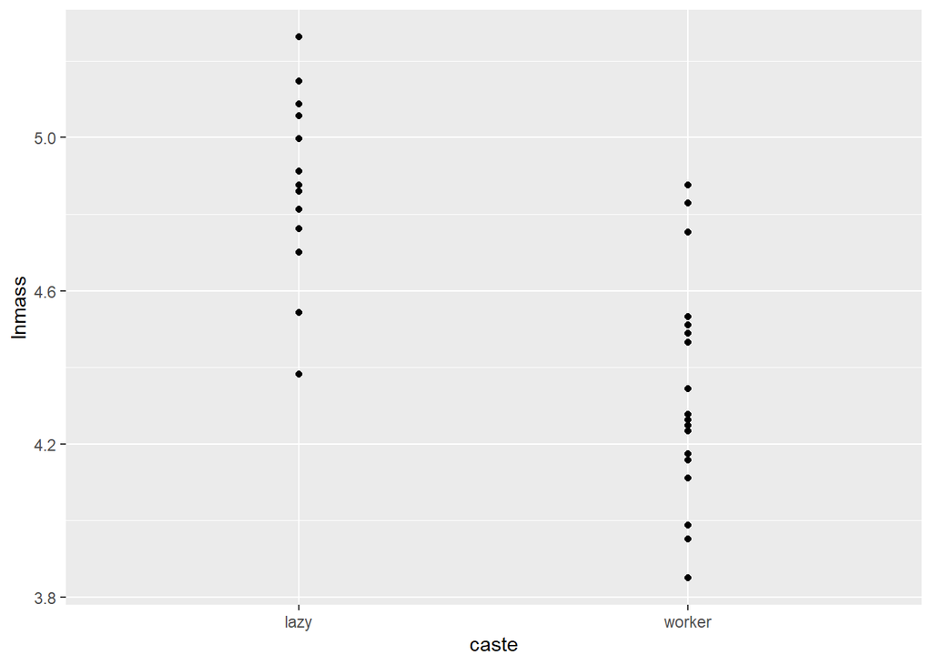

```r
molerat_plot <- molerat |>
  ggplot(mapping = aes(x = caste,
                       y = lnmass))+
  geom_point()
molerat_plot
```

Fitting a model

```r
molerat_lm <- lm(formula = lnmass ~ caste, data = molerat)
molerat_lm
```

```
##
## Call:
## lm(formula = lnmass ~ caste, data = molerat)
##
## Coefficients:
## (Intercept)  casteworker
##      4.8643      -0.5403
```

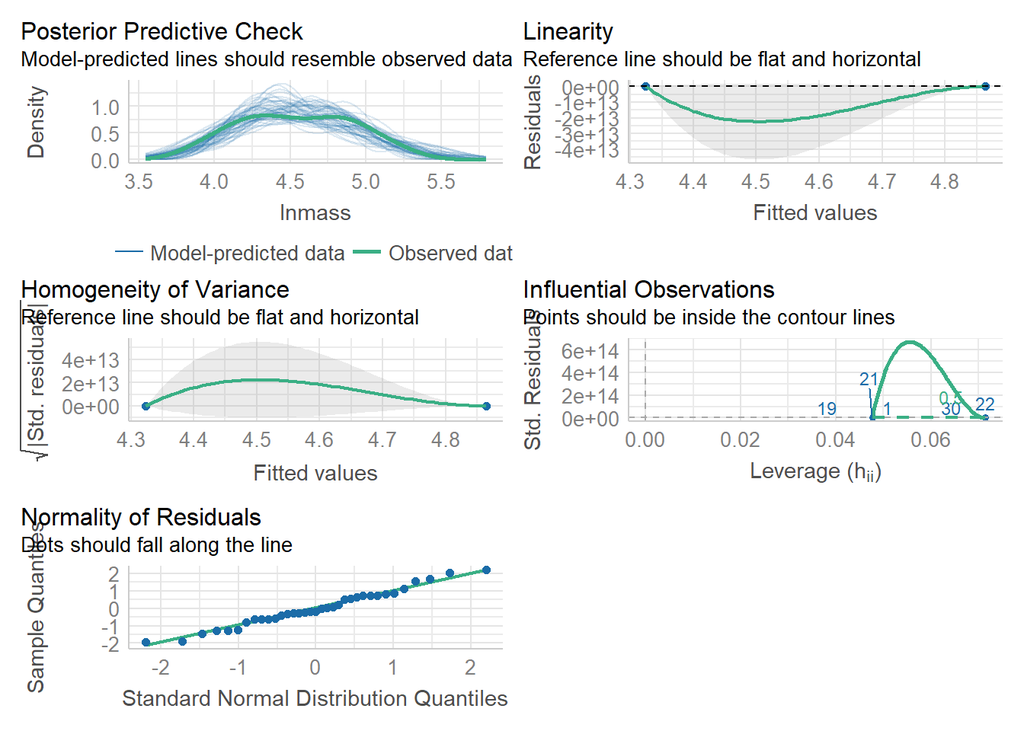

```r
check_model(molerat_lm)
```

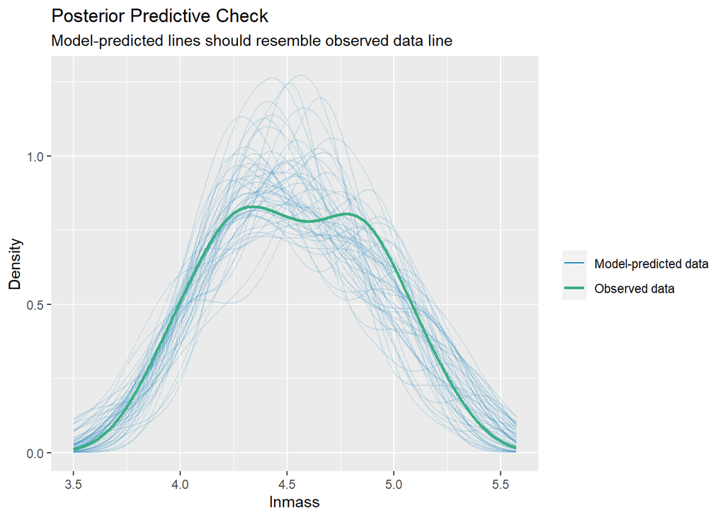

```r
#checking predictions
check_predictions(molerat_lm) |> plot()
```

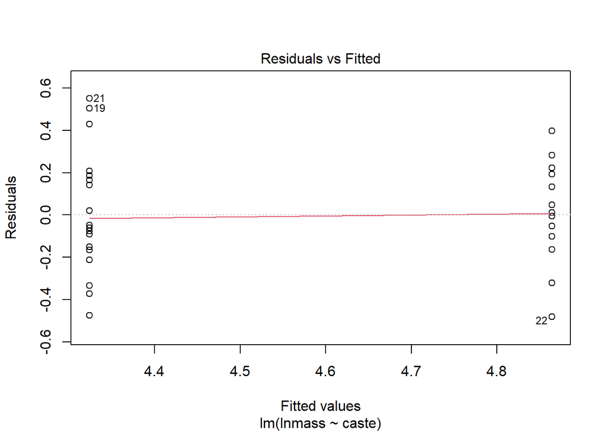

```r
# checking linearity
plot(molerat_lm, which = 1)
```

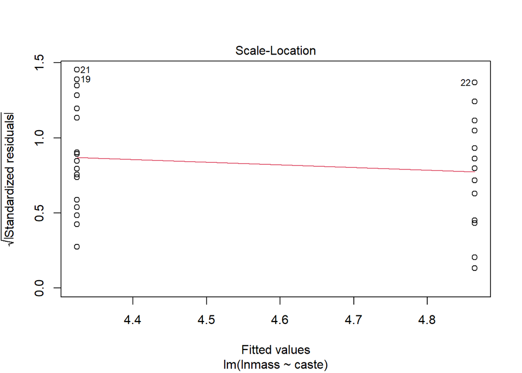

```r
# Checking HOV
plot(molerat_lm, which = 3)
```

```
## For confidence bands, please install `qqplotr`.
```

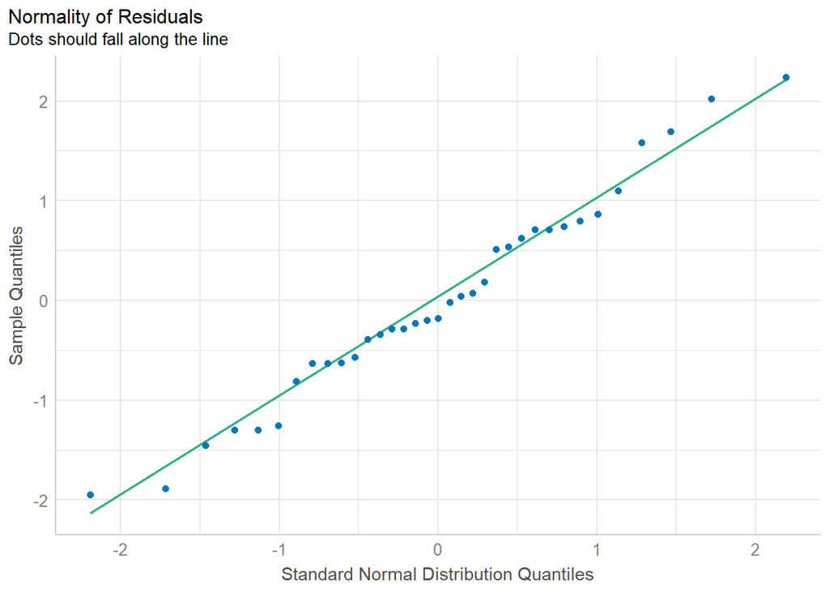

```r
# Checking normality
check_normality(molerat_lm) |> plot(type = "qq")
```

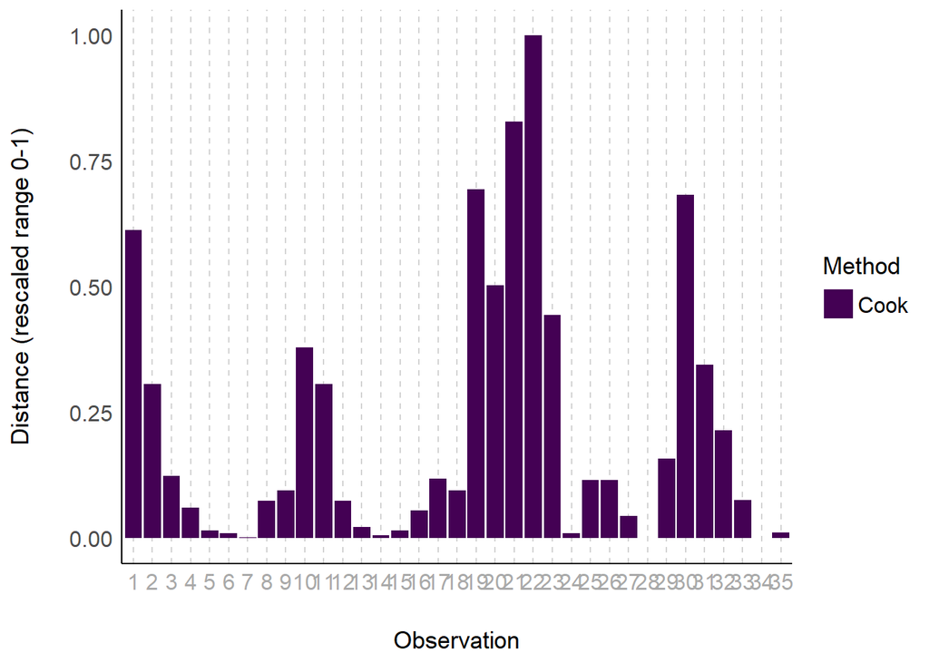

```r
# Checking outliers
check_outliers(molerat_lm) |> plot(type = "bar")
```

The model fits quite well with no real violation of assumptions here. This is probably due to the values being log values but that is just a speculation. Every assumption is pretty well met as evident by the different plot()s

Comparing the two castes log mass values

```r
# Comparing coefficients
tidy(molerat_lm)
```

```
## # A tibble: 2 × 5
##   term        estimate std.error statistic  p.value
##   <chr>          <dbl>     <dbl>     <dbl>    <dbl>
## 1 (Intercept)    4.86     0.0715     68.1  4.59e-37
## 2 casteworker   -0.540    0.0923     -5.85 1.48e- 6
```

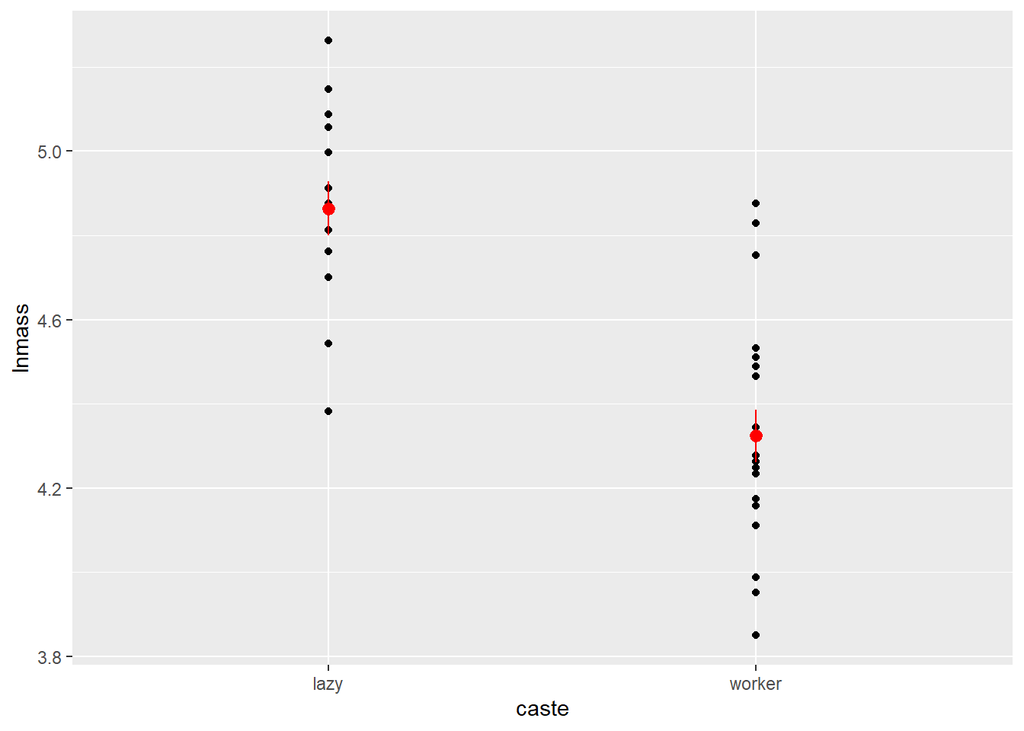

```r
# comparing with a plot
molerat_plot+
  stat_summary(fun.data = "mean_se", color = "red")
```

```r
#comparing r2
r2(molerat_lm)
```

```
## # R2 for Linear Regression
##        R2: 0.510
##   adj. R2: 0.495
```

```r
# comparing estimated means
library(emmeans)
molemeans <- emmeans(molerat_lm, specs = ~ caste)
molemeans
```

```
##  caste  emmean     SE df lower.CL upper.CL
##  lazy     4.86 0.0715 33     4.72     5.01
##  worker   4.32 0.0584 33     4.21     4.44
##
## Confidence level used: 0.95
```

```r
# comparing these means
mole_cont <- contrast(molemeans, method = "pairwise")
mole_cont
```

```
##  contrast      estimate     SE df t.ratio p.value
##  lazy - worker     0.54 0.0923 33   5.855  <.0001
```

```r
# T.test
t.test(lnmass ~ caste, data = molerat,
       var.equal = TRUE,
       conf.level= 0.95)
```

```
##
##  Two Sample t-test
##
## data:  lnmass by caste
## t = 5.8548, df = 33, p-value = 1.479e-06
## alternative hypothesis: true difference in means between group lazy and group worker is not equal to 0
## 95 percent confidence interval:
##  0.3525265 0.7280069
## sample estimates:
##   mean in group lazy mean in group worker
##             4.864253             4.323986
```

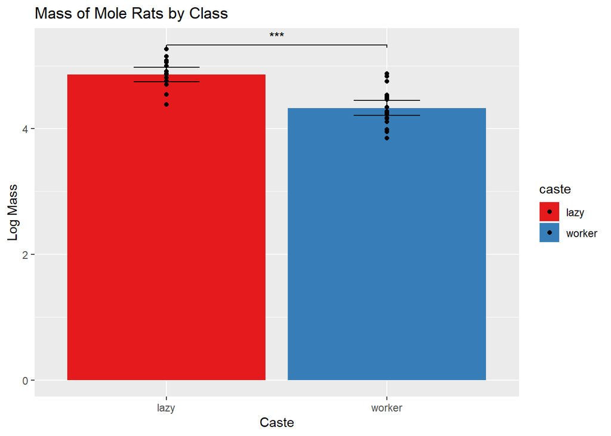

```r
# Publication ready plot
library(ggsignif)
ggplot(data = molerat, mapping = aes(x = caste,
                                     y = lnmass,
                                     fill = caste))+

  stat_summary(fun.data = mean_sdl, geom = "bar")+
  stat_summary(fun.data = mean_cl_boot, geom = "errorbar", width = 0.3)+
  geom_point()+
  labs(title = "Mass of Mole Rats by Class")+
  xlab(label = "Caste")+
  ylab(label = "Log Mass")+
  scale_fill_brewer(palette = "Set1")+
  geom_signif(comparisons = list(c("lazy", "worker")),
              map_signif_level = TRUE)
```

I would say that these values are different due to the contrast performed on the estimated means. It reported back a low p value with an estimate difference of .54 and low SE. Also the estimated means reported the confidence intervals not intersecting 0 which I would interpret as these groups are different from each other. A t.test confirms this.

## Comparing Many Means

Data is lodgepole pinecones from different habitats Plotting the plot

```r
pinecones <- read_csv("https://www.zoology.ubc.ca/~whitlock/ABD/teaching/datasets/15/15q22LodgepolePineCones.csv")
```

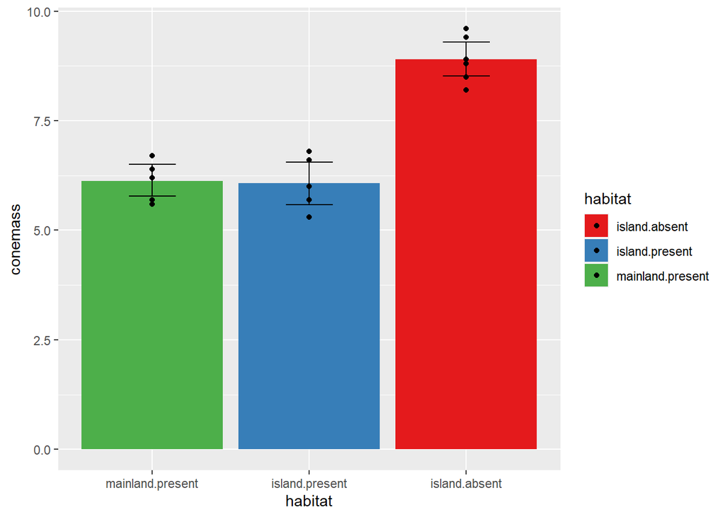

```r
pinecone_plot <- pinecones |>
  ggplot(mapping = aes(x = habitat,
                       y = conemass,
                       fill = habitat)) +
  stat_summary(fun.data = mean_sdl, geom = "bar")+
  stat_summary(fun.data = mean_cl_boot, geom = "errorbar", width = 0.3)+
  geom_point() +
  scale_fill_brewer(palette = "Set1")+
  geom_signif(comparisons = list(c("Island.Absent", "Island.Present", "Mainland.Present")),
              map_signif_level = TRUE)+
  scale_x_discrete(limits = rev)
pinecone_plot
```

Fitting a model with LS and evaluate relevant assumptions.

```r
pinecone_lm <- lm(formula = conemass ~ habitat, data = pinecones)
pinecone_lm
```

```
##
## Call:
## lm(formula = conemass ~ habitat, data = pinecones)
##
## Coefficients:
##             (Intercept)    habitatisland.present  habitatmainland.present
##                    8.90                    -2.82                    -2.78
```

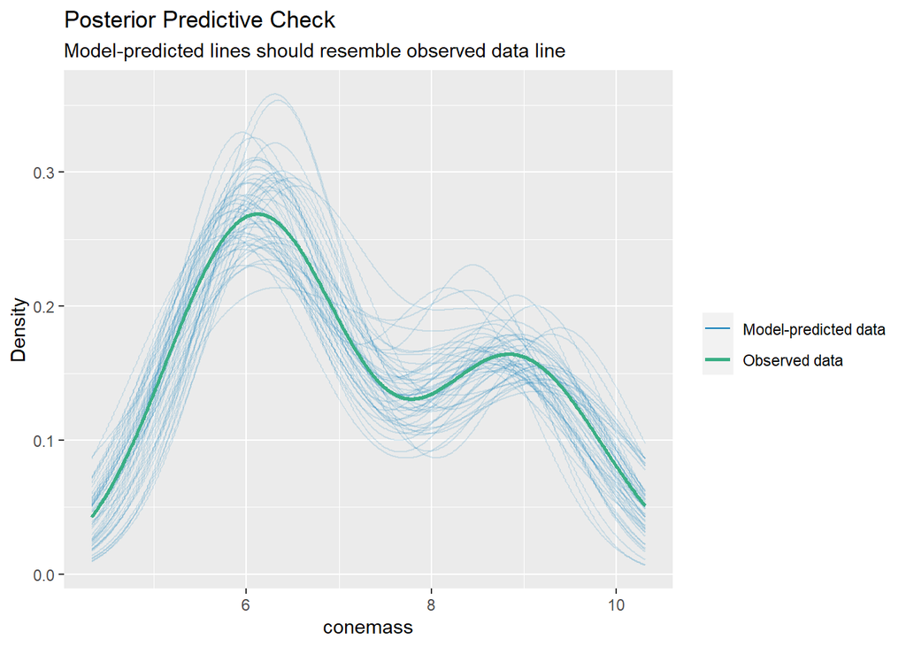

```r
# Checking assumptions
#checking predictions
check_predictions(pinecone_lm) |> plot()
```

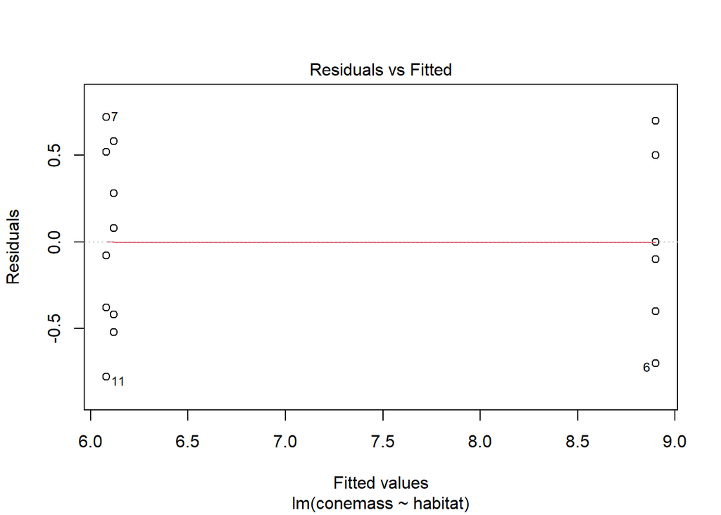

```r
# checking linearity
plot(pinecone_lm, which = 1)
```

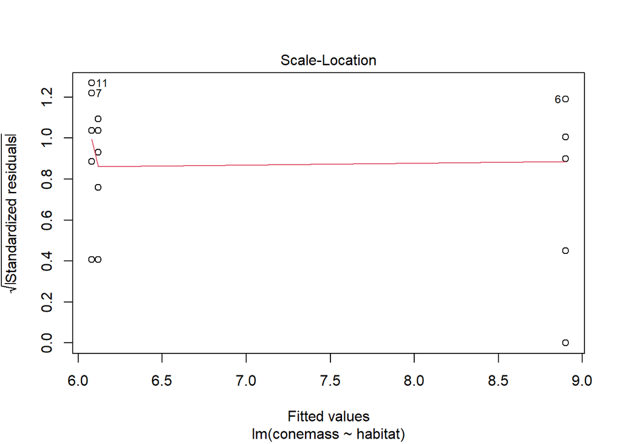

```r
# Checking HOV
plot(pinecone_lm, which = 3)
```

```
## For confidence bands, please install `qqplotr`.
```

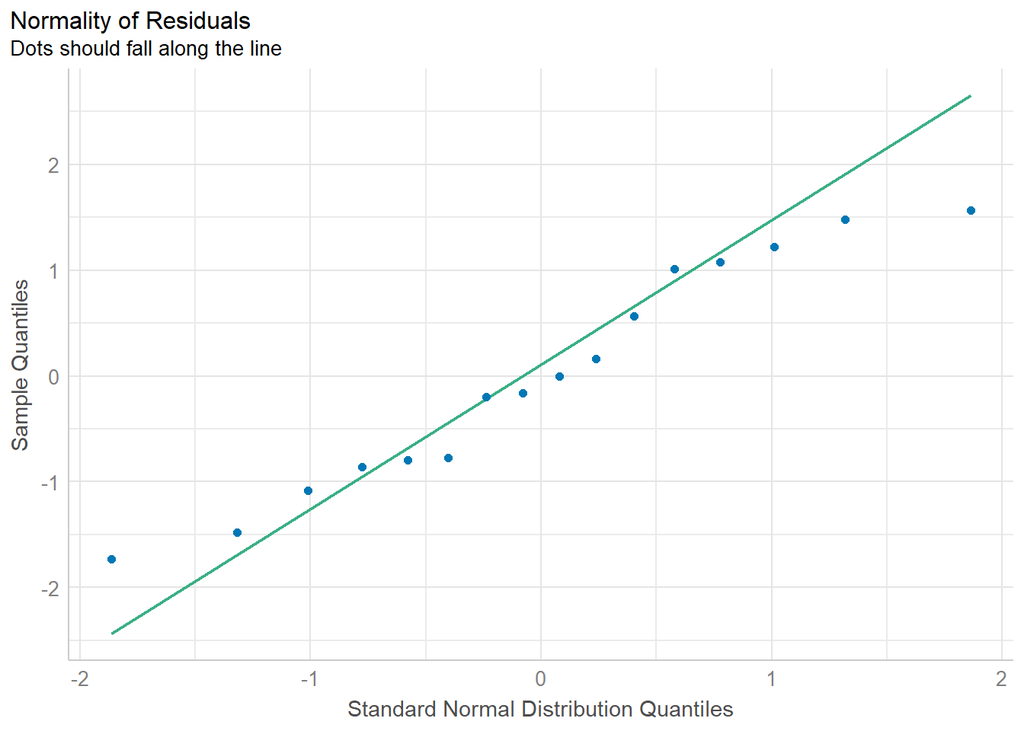

```r
# Checking normality
check_normality(pinecone_lm) |> plot(type = "qq")
```

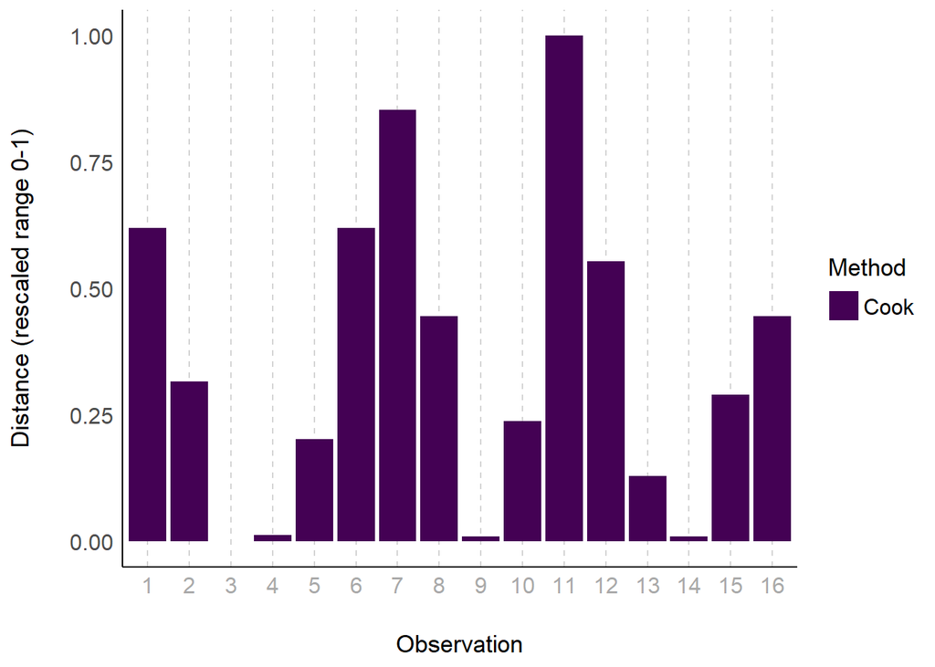

```r
# Checking outliers
check_outliers(pinecone_lm) |> plot(type = "bar")
```

I think this data passes all of the assumptions and requires no fix. So, we can use this model.

How much variation is explained by my model?

```r
r2(pinecone_lm)
```

```
## # R2 for Linear Regression
##        R2: 0.885
##   adj. R2: 0.867
```

About 86% of the variation can be explained by our model.

Showing which means are different from each other.

```r
pinemeans <- emmeans(pinecone_lm, specs = ~ habitat)
pinemeans
```

```
##  habitat          emmean    SE df lower.CL upper.CL
##  island.absent      8.90 0.221 13     8.42     9.38
##  island.present     6.08 0.242 13     5.56     6.60
##  mainland.present   6.12 0.242 13     5.60     6.64
##
## Confidence level used: 0.95
```

```r
pine_cont <- contrast(pinemeans, method = "pairwise")
pine_cont
```

```
##  contrast                          estimate    SE df t.ratio p.value
##  island.absent - island.present        2.82 0.328 13   8.596  <.0001
##  island.absent - mainland.present      2.78 0.328 13   8.474  <.0001
##  island.present - mainland.present    -0.04 0.343 13  -0.117  0.9925
##
## P value adjustment: tukey method for comparing a family of 3 estimates
```

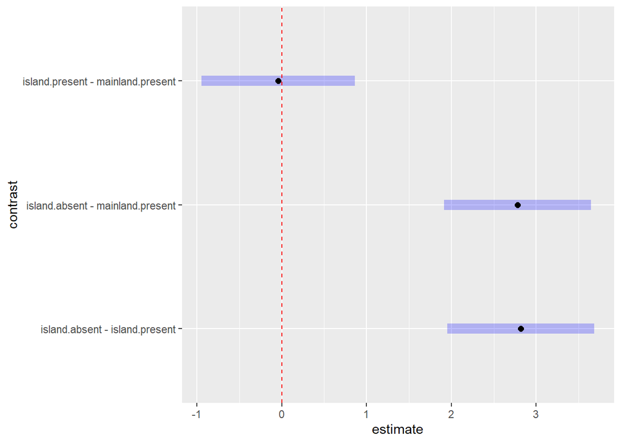

```r
pine_cont|>
  plot()+
  geom_vline(xintercept = 0, color = "red", lty = 2)
```

Using a 95% confidence Interval means were generated. And compared with the contrast function. This reported the difference in means as 2.82, 2.78 and ~0. between the 3 combos of groups. I decided to use 95% CI because the errors were low and the data were randomly collected.

## Categorical Variables and Transformation

Getting the data

```r
cages <- read_csv("https://biol607.github.io/homework/data/fouling_transplant_data.csv")
cages_fix <- cages|>
  mutate(treatment = paste(cages$Caged, cages$`Position On Block`))
```

Plotting the data

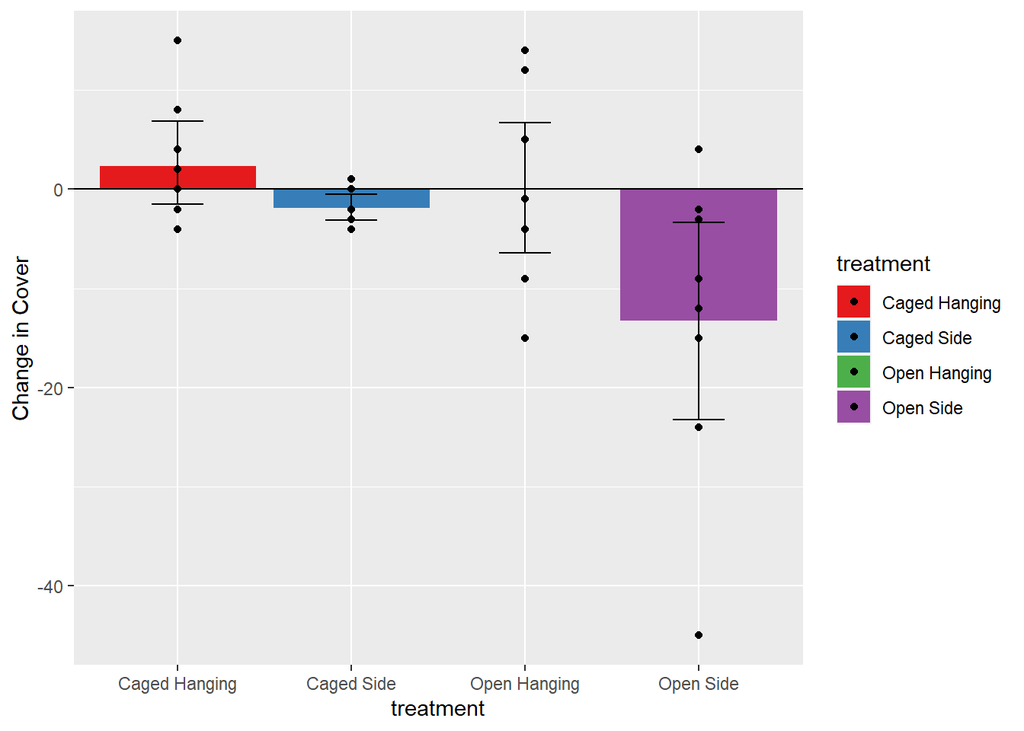

```r
cages_plot <- ggplot(data = cages_fix, mapping = aes(x = treatment,
                                                     y = `Change in Cover`,
                                                     fill = treatment))+
  stat_summary(fun.data = mean_sdl, geom = "bar")+
  stat_summary(fun.data = mean_cl_boot, geom = "errorbar", width = 0.3)+
  geom_point() +
  scale_fill_brewer(palette = "Set1")+
  geom_hline(yintercept = 0, color = "black")
cages_plot
```

Fitting amodel and exploring how treatment influences cover change and evaluating assumptions

```r
# Fitting a model
cages_lm <- lm(formula = `Change in Cover` ~ treatment, data = cages_fix)
cages_lm
```

```
##
## Call:
## lm(formula = `Change in Cover` ~ treatment, data = cages_fix)
##
## Coefficients:
##           (Intercept)    treatmentCaged Side  treatmentOpen Hanging
##                 2.375                 -4.250                 -2.250
##    treatmentOpen Side
##               -15.625
```

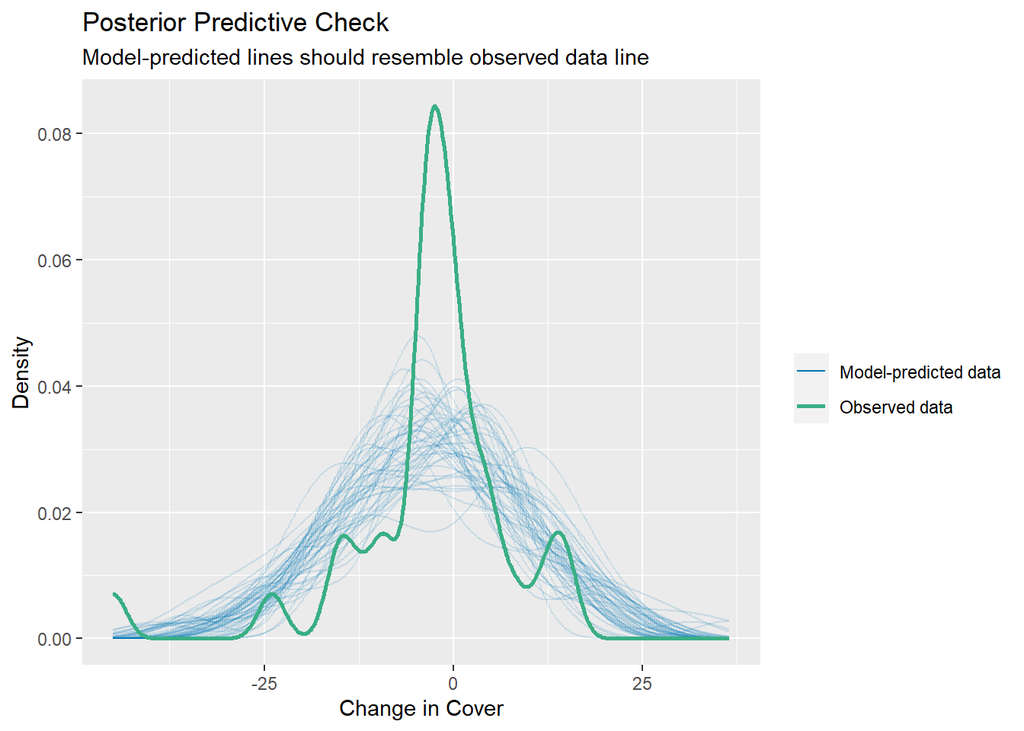

```r
# Checking assumptions
#checking predictions
check_predictions(cages_lm) |> plot()
```

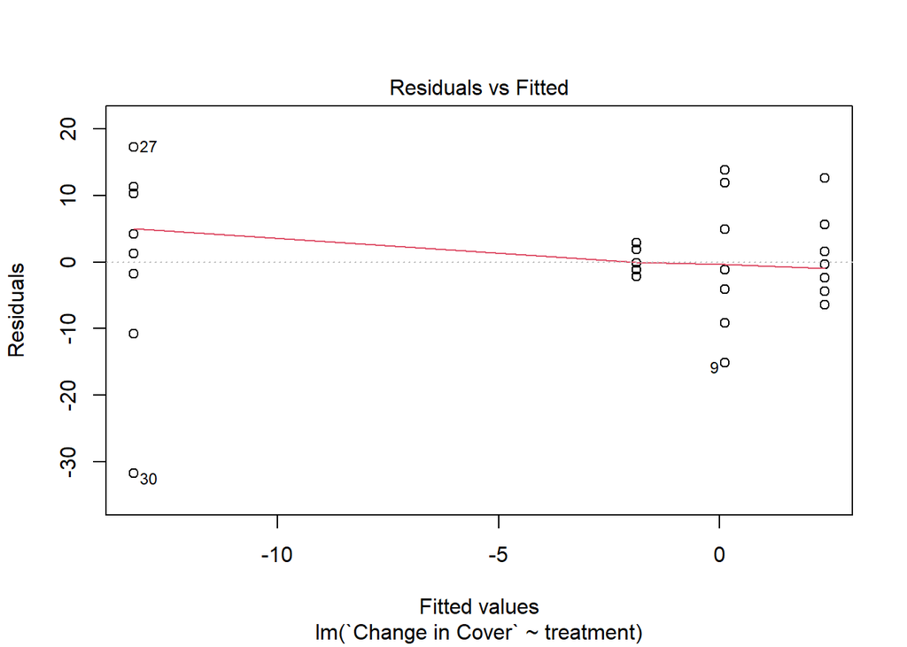

```r
# checking linearity
plot(cages_lm, which = 1)
```

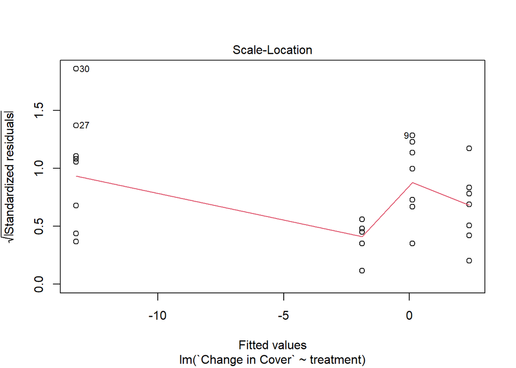

```r
# Checking HOV
plot(cages_lm, which = 3)
```

```
## For confidence bands, please install `qqplotr`.
```

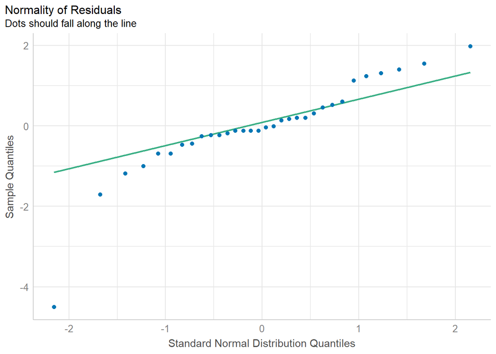

```r
# Checking normality
check_normality(cages_lm) |> plot(type = "qq")
```

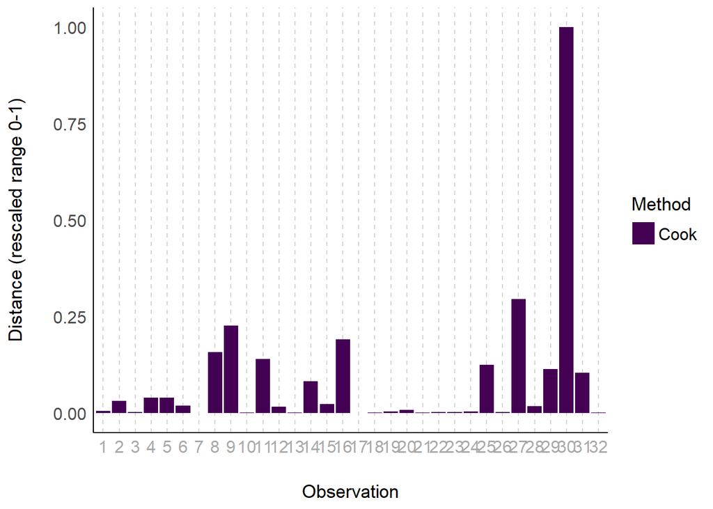

```r
# Checking outliers
check_outliers(cages_lm) |> plot(type = "bar")
```

Transforming the data by dividing

```r
cage_lm_trans1 <- lm(formula = (`Change in Cover`/ `Initial Cover`) ~ treatment,
                                data = cages_fix)
cage_lm_trans1
```

```
##
## Call:
## lm(formula = (`Change in Cover`/`Initial Cover`) ~ treatment,
##     data = cages_fix)
##
## Coefficients:
##           (Intercept)    treatmentCaged Side  treatmentOpen Hanging
##               0.03225               -0.07958               -0.07608
##    treatmentOpen Side
##              -0.34959
```

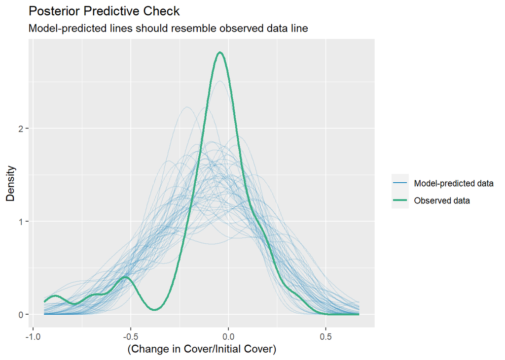

```r
# Checking assumptions
#checking predictions
check_predictions(cage_lm_trans1) |> plot()
```

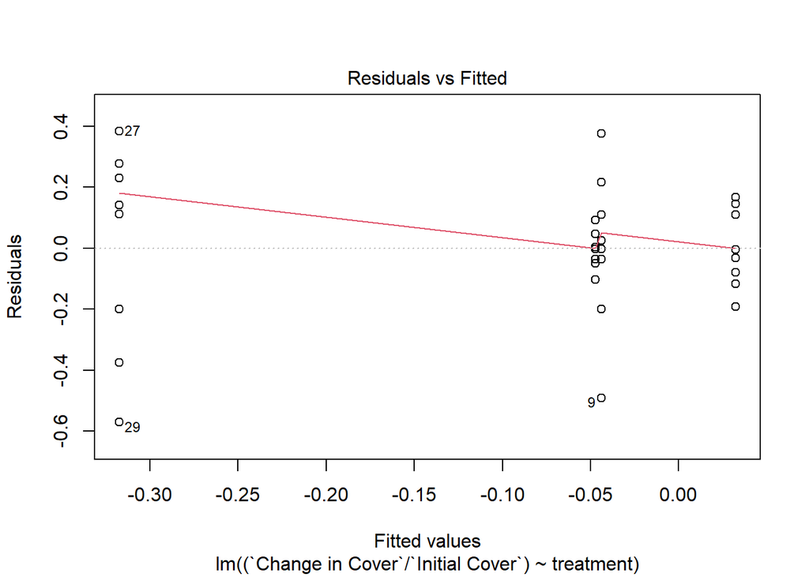

```r
# checking linearity
plot(cage_lm_trans1, which = 1)
```

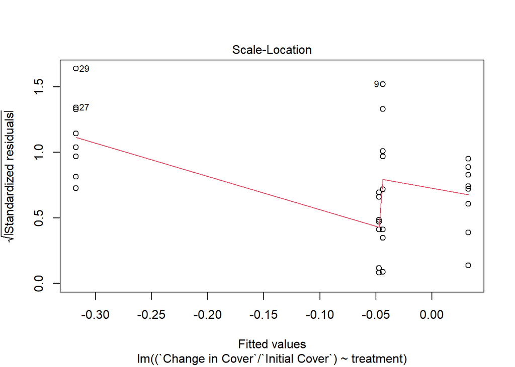

```r
# Checking HOV
plot(cage_lm_trans1, which = 3)
```

```
## For confidence bands, please install `qqplotr`.
```

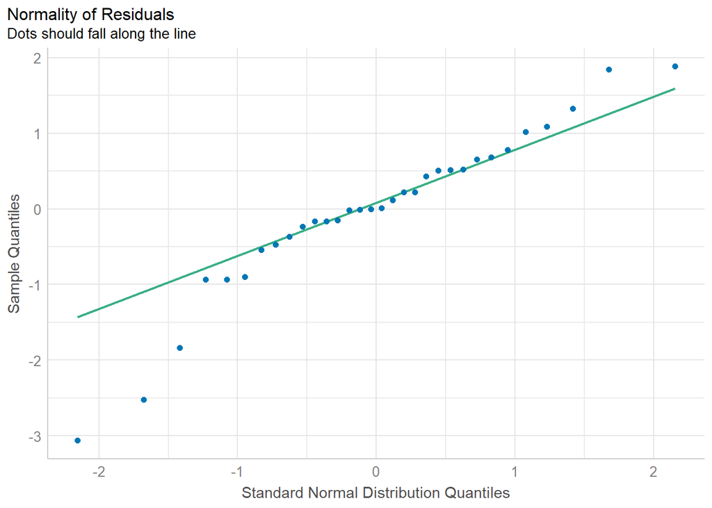

```r
# Checking normality
check_normality(cage_lm_trans1) |> plot(type = "qq")
```

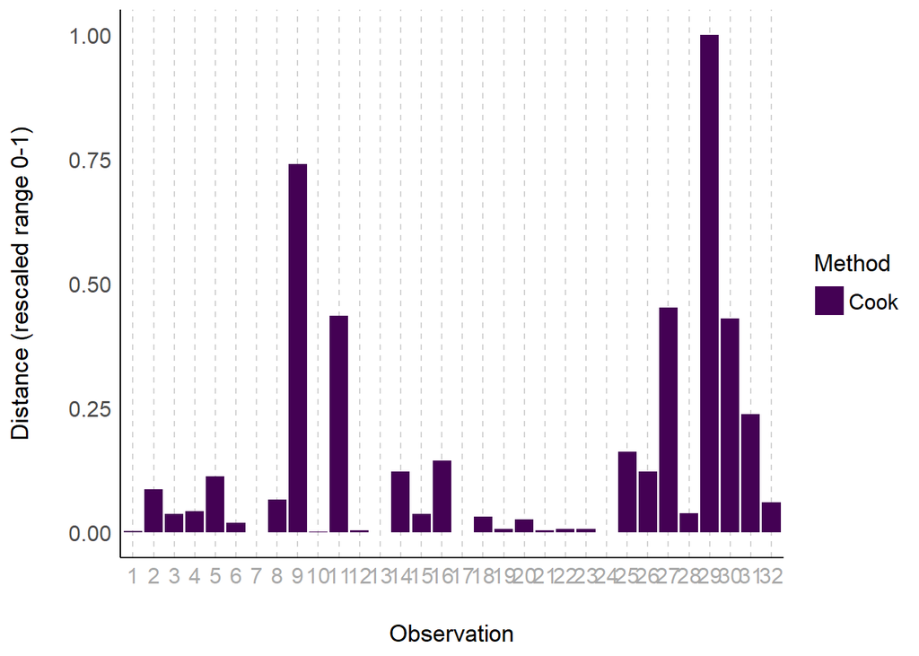

```r
# Checking outliers
check_outliers(cage_lm_trans1) |> plot(type = "bar")
```

Transforming the data by logit cover

```r
library(car)
cage_lm_trans2 <- lm(formula = (logit(`Initial Cover`) - logit(`Final Cover`)) ~ treatment, data = cages_fix)
```

```
## Note: largest value of p > 1 so values of p interpreted as percents
```

```
## Note: largest value of p > 1 so values of p interpreted as percents
```

```r
cage_lm_trans2
```

```
##
## Call:
## lm(formula = (logit(`Initial Cover`) - logit(`Final Cover`)) ~
##     treatment, data = cages_fix)
##
## Coefficients:
##           (Intercept)    treatmentCaged Side  treatmentOpen Hanging
##               -0.3853                 0.4821                 0.3030
##    treatmentOpen Side
##                1.1860
```

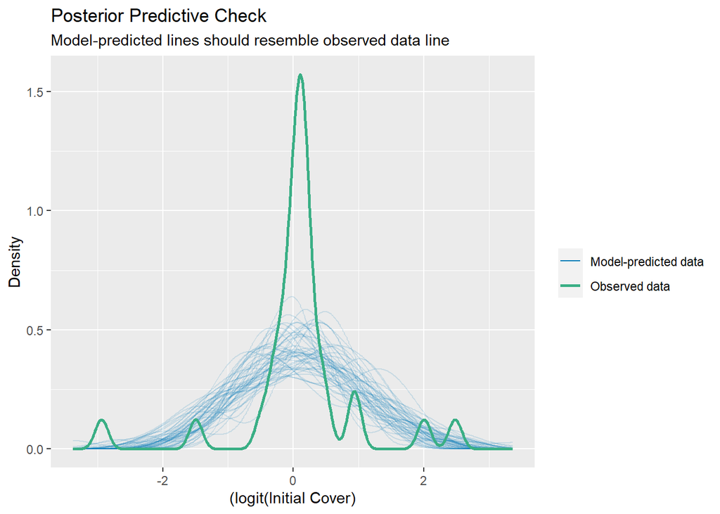

```r
# Checking assumptions
#checking predictions
check_predictions(cage_lm_trans2) |> plot()
```

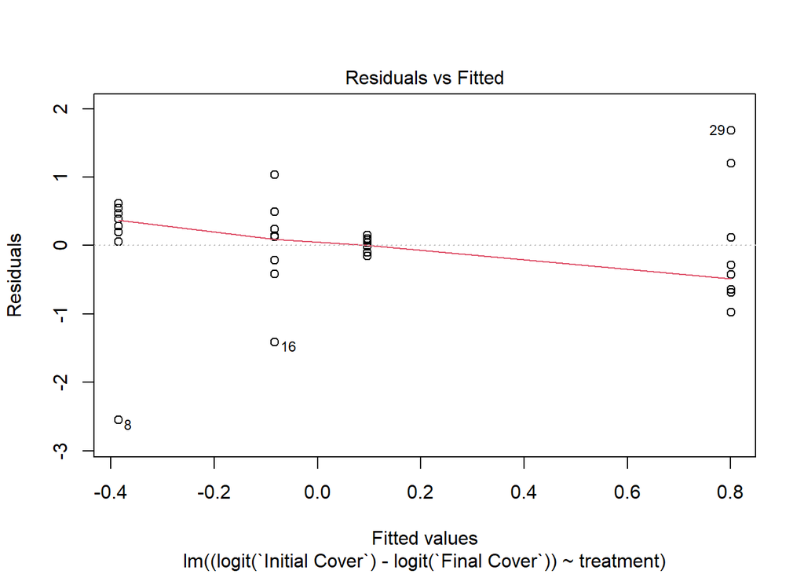

```r
# checking linearity
plot(cage_lm_trans2, which = 1)
```

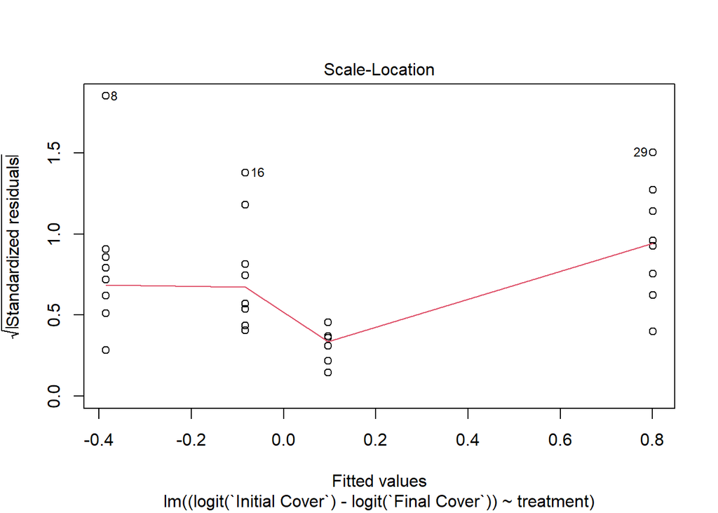

```r
# Checking HOV
plot(cage_lm_trans2, which = 3)
```

```
## For confidence bands, please install `qqplotr`.
```

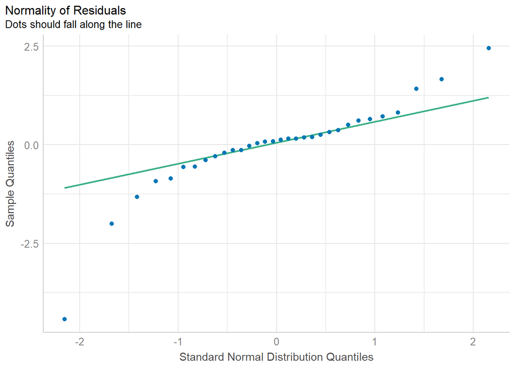

```r
# Checking normality
check_normality(cage_lm_trans2) |> plot(type = "qq")
```

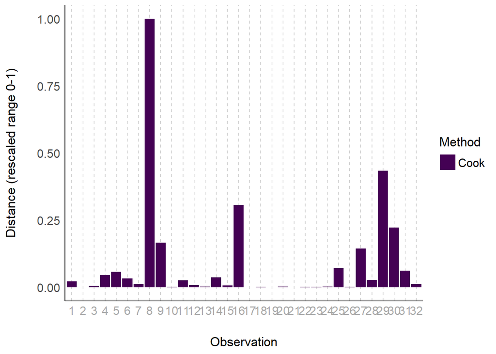

```r
# Checking outliers
check_outliers(cage_lm_trans2) |> plot(type = "bar")
```

I would say the first transformation worked the best because it better fit in the assumptions than the logit transformation. Going forward I would use that first transformation.